# Estatística Bayesiana — síntese para consulta

Do teorema de Bayes a uma análise completa

Autor

João Paulo Gusmão Teixeira (JPGTEIXEIRA)

Data de Publicação

26 de novembro de 2026

**Como usar.** Cada tópico tem o texto à esquerda e o código à direita. O código é um *modelo*: copie, troque os dados e o modelo, e siga os mesmos passos. Todos os gráficos vêm de **um único exemplo**: o saldo de gols do Vasco em função do público em São Januário. Os dados são **simulados**, e os parâmetros verdadeiros são assumidamente **mentirosos** (otimistas, sou vascaíno). A vantagem de ter dados simulados é que sabemos a resposta certa. As caixas laranja são os cuidados; as azuis, onde aprofundar. Busquei referenciar tanto o material da disciplina quanto de sites externos.

*Versão da disciplina EST613 (UFV, 2026/2, Profa. Camila Ferreira Azevedo): os links “Aula” e “Códigos” levam ao material no Drive da turma. Fiz um segundo código que traz somente links externos*

# 1. Bayes em uma página

**De onde vem.** Thomas Bayes (1702–1761), reverendo e matemático inglês. O ensaio foi publicado depois da sua morte, em 1763, por Richard Price: [*An Essay towards Solving a Problem in the Doctrine of Chances*](https://royalsocietypublishing.org/rstl/article/doi/10.1098/rstl.1763.0053/119736/LII-An-essay-towards-solving-a-problem-in-the).

**A ideia central** é que a probabilidade também mede **grau de crença**, e não só frequência, portanto temos duas leituras:

- **objetiva:** vem de um mecanismo aleatório conhecido (dado, baralho, Mega-Sena);
- **subjetiva:** é a crença sobre algo incerto: “qual a chance de chover amanhã?”, “qual a chance de o Vasco vencer, dado que joga contra o time x?”. Esta segunda pergunta vai nos acompanhar no documento inteiro.

Sem informação para preferir um resultado a outro, todos são igualmente prováveis: **princípio da razão insuficiente** (ou da indiferença). Um torcedor vascaíno, claro, nunca está nessa situação.

O quadro abaixo resume as principais diferenças entre a estatística frequentista e a bayesiana.

|  | Frequentista | Bayesiana |
| --- | --- | --- |
| Parâmetro $\theta$ | fixo e desconhecido | desconhecido e **descrito por uma distribuição** |
| O que é aleatório | o estimador $\hat\theta$ (muda com a amostra) | $\theta$ (a nossa incerteza sobre ele) |
| Informação prévia | não entra | entra pela **priori** (inclusive a fé do torcedor) |
| Resultado | estimativa + IC + valor-p | **distribuição a posteriori** inteira |
| Intervalo de 95% | 95% dos intervalos *construídos assim* contêm $\theta$ | $P(\theta \in \text{intervalo} \mid y) = 0{,}95$ |
| Hipóteses | rejeita ou não $H_0$ | $P(H_0 \mid y)$ e $P(H_1 \mid y)$ |

### O teorema

$$\underbrace{p(\theta \mid y)}_{\text{posteriori}}
= \frac{\overbrace{p(y \mid \theta)}^{\text{verossimilhança}}\;\overbrace{p(\theta)}^{\text{priori}}}
{\underbrace{p(y)}_{\text{evidência}}}
\;\;\propto\;\; p(y \mid \theta)\,p(\theta)$$

- **priori** $p(\theta)$: o que se sabe de $\theta$ *antes* dos dados;
- **verossimilhança** $p(y \mid \theta)$: o quanto cada valor de $\theta$ explica os dados (é função de $\theta$, com $y$ fixo);
- **evidência** $p(y) = \int p(y\mid\theta)p(\theta)\,d\theta$: constante que faz a posteriori integrar 1. Para inferir sobre $\theta$, muitas vezes nem precisa ser calculada; na comparação de modelos (fator de Bayes), passa a ser fundamental;
- **posteriori** $p(\theta \mid y)$: o que se sabe *depois*. Ela vira a priori da próxima vez que chegarem dados (**aprendizado sequencial**).

**Exemplo com conta fechada (Beta–Binomial).** $\theta$ = chance de o Vasco vencer um jogo. A priori é “de torcedor”, Beta(8, 2): antes de qualquer jogo, já se acha que o Vasco vence 80% das vezes. Os dados (simulados, e generosos) dizem que o Vasco venceu 15 dos últimos 20 jogos. A conta fecha porque a Beta é conjugada da Binomial, então a posteriori sai da mesma família da priori, só com os parâmetros atualizados (para saber mais, vá para a seção 2.4). Com priori Beta($a$, $b$) e $y$ vitórias em $n$ jogos, a posteriori é Beta($a + y$, $b + n - y$) = Beta(23, 7).

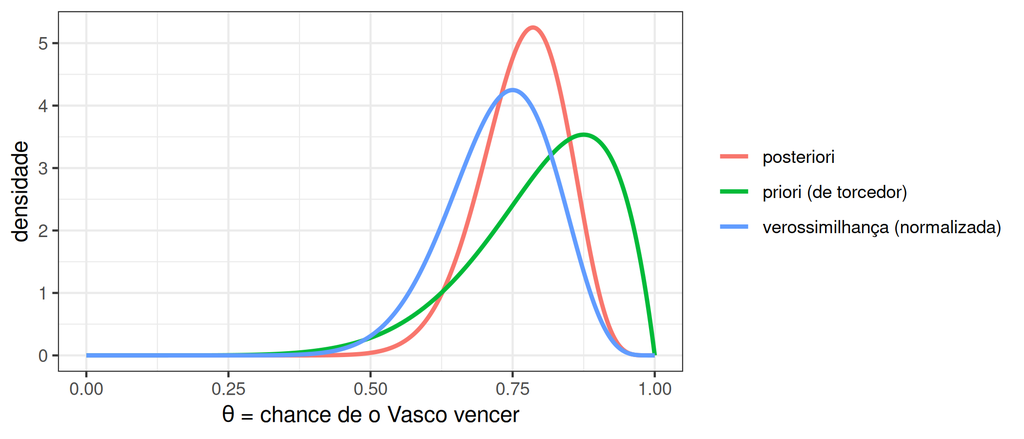

```r
y <- 15; n <- 20      # dados: 15 vitórias em 20 jogos
a <- 8;  b <- 2       # priori de torcedor: Beta(8, 2)
th <- seq(0, 1, length.out = 400)
d <- rbind(
  data.frame(th, dens = dbeta(th, a, b), curva = "priori (de torcedor)"),
  data.frame(th, dens = dbeta(th, y + 1, n - y + 1),
             curva = "verossimilhança (normalizada)"),
  data.frame(th, dens = dbeta(th, a + y, b + n - y),
             curva = "posteriori"))
ggplot(d, aes(th, dens, colour = curva)) +
  geom_line(linewidth = 1) +
  labs(x = expression(theta ~ "= chance de o Vasco vencer"),
       y = "densidade", colour = NULL)
```

```r
(a + y) / (a + b + n)  # média a posteriori
```

```
[1] 0.7666667
```

A posteriori fica **entre** a priori e os dados, mais perto de quem tem mais informação. Aqui, 20 jogos pesam o dobro dos “10 jogos imaginários” da priori.

Para aprofundar

- [Bayes Rules!, caps. 1–3](https://www.bayesrulesbook.com/) (livro aberto, muito didático) · [O ensaio de 1763](https://doi.org/10.1098/rstl.1763.0053)
- Aula: [Tópico 1 – Introdução e probabilidade](https://drive.google.com/file/d/1yxZ7o-tXp-hPLa0khXaPgnodS3tYObrq/view) · Códigos: [Módulo I – Teorema de Bayes por simulação](https://drive.google.com/file/d/1To6E3BMAk1cVenkf37pT4BKkgbyDujr7/view)

# 2. O roteiro de uma análise

Pergunta e dados→ Verossimilhança→ Priori + checagem a priori→ Posteriori (fórmula ou MCMC)→ Convergência→ Adequação→ Comparação→ Inferência e hipóteses→ Sensibilidade

Se a convergência ou a adequação falharem, volte ao modelo (verossimilhança e priori).

Ajustar não é o fim: **ajustar → verificar → comparar → interpretar**. Cada passo abaixo segue esta ordem.

## 2.1 Pergunta e dados

Antes de qualquer conta: **o que se quer saber** (um parâmetro? uma previsão? comparar grupos?) e **como os dados foram gerados**. O modelo é uma história de como os dados nasceram.

**Pergunta:** a torcida empurra o Vasco? E qual a chance de vencer o próximo jogo?

**Dados:** 60 jogos em São Januário. $y$ = saldo de gols (gols do Vasco − gols do adversário); $x$ = público, em milhares. O modelo:

$$y_i = \beta_0 + \beta_1 x_i + \varepsilon_i,\qquad \varepsilon_i \sim N(0, \sigma^2)$$

Valores verdadeiros (mentirosos): $\beta_0 = 0$ (de portões fechados, empate), $\beta_1 = 0{,}12$ gol a mais por mil torcedores (com São Januário lotado, quase 3 gols de saldo), $\sigma = 1{,}2$.

**Vitória** = saldo positivo. Então a chance de vencer não é um parâmetro do modelo: ela sai da **preditiva a posteriori**, $P(\tilde y > 0 \mid y)$ (ver 2.10).

Atenção

- Simular dados com valores conhecidos e ver se o modelo os recupera é o melhor teste de um código novo (mesmo que os valores sejam mentirosos).
- O saldo de gols é inteiro, e a Normal é contínua: é uma aproximação. Voltamos a isso na adequação.
- Olhe os dados antes (gráfico, escala, valores impossíveis, faltantes).

```r
set.seed(2026)
n  <- 60                              # jogos
x <- round(runif(n, 5, 22), 1)        # público (mil)
y <- round(0 + 0.12 * x + rnorm(n, 0, 1.2))   # saldo de gols
dados <- list(N = n, x = x, y = y)    # lista: formato do Stan
table(resultado = sign(y))            # -1 derrota, 0 empate, 1 vitória
```

```
resultado
-1  0  1
 3 11 46
```

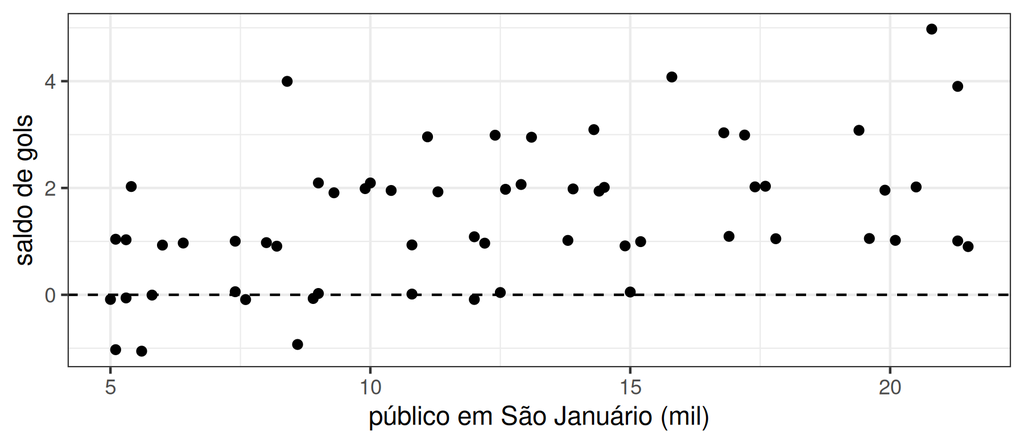

```r
ggplot(data.frame(x, y), aes(x, y)) +
  geom_jitter(height = 0.1, width = 0) +
  geom_hline(yintercept = 0, linetype = 2) +
  labs(x = "público em São Januário (mil)", y = "saldo de gols")
```

## 2.2 Verossimilhança

É a probabilidade dos dados vista como **função dos parâmetros**. Com observações independentes, é o produto das densidades:

$$L(\theta \mid y) = \prod_{i=1}^{n} p(y_i \mid \theta)$$
$$\log L(\theta \mid y) = \sum_{i=1}^{n} \log p(y_i \mid \theta)$$

Ela não é uma distribuição para $\theta$ (não precisa integrar 1). O valor que a maximiza é o EMV, o ponto de partida frequentista.

Atenção

- Trabalhe sempre com o **log** (o produto de muitas densidades pequenas vira zero no computador).
- Escolha a família pelo tipo do dado: contagem → Poisson/Binomial negativa; proporção → Binomial; contínuo positivo → Gama/Lognormal; contínuo → Normal ou *t* (mais robusta a valores extremos).
- Guarde o **log-verossimilhança por observação** (`log_lik`): é ele que o WAIC e o LOO usam.

```r
# log-verossimilhança da regressão
loglik <- function(b0, b1, sigma, x, y)
  sum(dnorm(y, mean = b0 + b1 * x, sd = sigma, log = TRUE))

loglik(0, 0.12, 1.2, x, y)    # valores verdadeiros: maior
```

```
[1] -92.91022
```

```r
loglik(-1, 0, 1.2, x, y)      # "Vasco perde sempre": muito menor
```

```
[1] -223.7145
```

Para aprofundar

- [Bayes Rules!, cap. 2](https://www.bayesrulesbook.com/) · Tabela de distribuições (escolher a família)
- Aula: [Tópico 3 – Função de verossimilhança](https://drive.google.com/file/d/1WjsCl2VQY13T9KYweR-auimW-BwQhiBw/view) · Códigos: [Módulo II – Verossimilhança, EMV, informação de Fisher](https://drive.google.com/file/d/1rXh5NOMvNpHzAKaMXUyyXyF8PLaVgPhG/view) · [Tópico 2 – Variável aleatória](https://drive.google.com/file/d/1AY3xJSWp6AQwy0w3v3ZlY0CviEhbWcTr/view)

## 2.3 Priori e checagem preditiva a priori

A priori resume o que se sabe **antes** dos dados. Tipos:

- **informativa:** traz conhecimento real (experimentos anteriores, literatura);
- **fracamente informativa:** só descarta o absurdo (o padrão recomendado hoje);
- **não informativa / vaga:** quase plana; cuidado, “plana” depende da escala;
- **conjugada:** gera posteriori da mesma família (conta fechada; ver tabela);
- **imprópria:** não integra 1; só vale se a posteriori for própria.

**Checagem preditiva a priori:** sorteie parâmetros **só da priori**, simule dados e veja se fazem sentido. Se a priori gera placares de 15 a 0 (para qualquer lado), ela está larga demais.

Atenção

- **Desvio-padrão × variância:** o livro e o JAGS escrevem $N(\mu, \sigma^2)$ ou $N(\mu, \tau)$ com precisão $\tau = 1/\sigma^2$; o R e o Stan usam o **desvio-padrão**.
- Para desvios-padrão: half-Normal ou half-Cauchy (Gelman, 2006); evite Inv-Gama($\varepsilon$, $\varepsilon$).
- Com **poucos grupos**, a priori dos desvios-padrão pesa muito: faça sensibilidade.

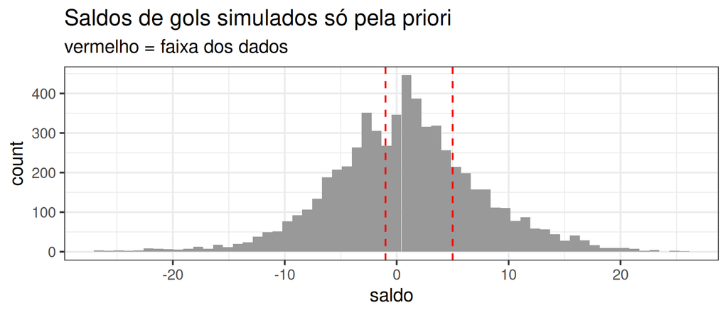

```r
# priori: b0 ~ N(0, 2), b1 ~ N(0, 0.5), sigma ~ half-N(0, 2)
S  <- 100                         # 100 "campeonatos possíveis"
b0 <- rnorm(S, 0, 2); b1 <- rnorm(S, 0, 0.5)
sg <- abs(rnorm(S, 0, 2))
y_prior <- sapply(1:S, function(s)
  rnorm(n, b0[s] + b1[s] * x, sg[s]))

ggplot(data.frame(saldo = as.vector(y_prior)), aes(saldo)) +
  geom_histogram(bins = 60, fill = "grey60") +
  geom_vline(xintercept = range(y), colour = "red", linetype = 2) +
  labs(title = "Saldos de gols simulados só pela priori",
       subtitle = "vermelho = faixa dos dados")
```

```r
mean(abs(y_prior) > 7)            # placares absurdos (7+ gols de saldo)
```

```
[1] 0.2673333
```

Aqui a priori é **vaga**: gera muitos saldos impossíveis, como 15 a 0. Os dados vão dominar, mas vale saber disso (e mencionar). Uma priori “de torcedor”, que só aceita vitórias, seria o erro oposto: veja a sensibilidade.

Para aprofundar

- [Recomendações de priori do Stan](https://github.com/stan-dev/stan/wiki/Prior-Choice-Recommendations) · [Gelman (2006): priori para variâncias](https://doi.org/10.1214/06-BA117A) · [Bayesian workflow (Gelman et al., 2020)](https://arxiv.org/abs/2011.01808)
- Aula: [Tópico 4 – Distribuição a priori](https://drive.google.com/file/d/1GySltdMUQ0sJGyHV4UgNcRWIdiyph198/view) · [Tópico 9 – Checagens preditivas](https://drive.google.com/file/d/1CjiIYuMoV3VE4JcJXMP0oE8bg8VZT-K9/view) · Códigos: [Módulo IV – Aprendizado bayesiano e efeito da priori](https://drive.google.com/file/d/1yuWeLi8VK84vIMb8UZVRTEGelOjTU2FD/view)

## 2.4 Posteriori: fórmula fechada ou MCMC

**Com priori conjugada**, a posteriori sai por conta (inferência exata):

| Dados | Priori | Posteriori |
| --- | --- | --- |
| Binomial($n$, $p$) | Beta($a$, $b$) | Beta($a + y$, $b + n - y$) |
| Poisson($\lambda$) | Gama($\alpha$, $\beta$) | Gama($\alpha + \sum y$, $\beta + n$) |
| Normal($\mu$, $\sigma^2$ conhecido) | N($\mu_0$, $\tau_0^2$) | N, média ponderada pelas precisões |

Na Normal: $\;\mu_{\text{post}} = \dfrac{\mu_0/\tau_0^2 + n\bar y/\sigma^2}{1/\tau_0^2 + n/\sigma^2}$.

**Sem forma fechada** (quase sempre: vários parâmetros, priori não conjugada), sorteamos amostras da posteriori com **MCMC**. O Stan só precisa do modelo escrito: `data` (o que se observa), `parameters` (o que se estima), `model` (priori + verossimilhança) e, opcionalmente, `generated quantities` (o que calcular com cada amostra: `log_lik`, dados replicados `y_rep`).

**Estimação × predição.** Estimar é falar de $\theta$ ($p(\theta\mid y)$); prever é falar de um dado novo ($p(\tilde y \mid y) = \int p(\tilde y\mid\theta)p(\theta\mid y)d\theta$, a **preditiva a posteriori**).

```stan
data {
  int<lower=1> N;
  vector[N] x;
  vector[N] y;
}
transformed data {
  real xbar = mean(x);    // centrar x: menos correlação
}
parameters {
  real b0c;               // saldo no público médio
  real b1;
  real<lower=0> sigma;    // com normal(): half-Normal
}
model {
  b0c   ~ normal(0, 2);   // priori
  b1    ~ normal(0, 0.5);
  sigma ~ normal(0, 2);
  // verossimilhança
  y ~ normal(b0c + b1 * (x - xbar), sigma);
}
generated quantities {
  real b0 = b0c - b1 * xbar;  // saldo com estádio vazio
  vector[N] log_lik;          // para WAIC/LOO
  vector[N] y_rep;            // checagem preditiva
  for (i in 1:N) {
    real mu = b0c + b1 * (x[i] - xbar);
    log_lik[i] = normal_lpdf(y[i] | mu, sigma);
    y_rep[i]   = normal_rng(mu, sigma);
  }
}
```

```r
# 4 cadeias x (2000 - 1000 de aquecimento) = 4000 amostras
fit <- sampling(modelo_reg, data = dados,
                chains = 4, iter = 2000, warmup = 1000,
                seed = 2026, refresh = 0)
```

Para aprofundar

- [BDA3, caps. 2–3](https://sites.stat.columbia.edu/gelman/book/BDA3.pdf) (PDF gratuito) · [Manuais do Stan](https://mc-stan.org/docs/)
- Aula: [Tópico 5 – Distribuição a posteriori](https://drive.google.com/file/d/1k2DWH8OZAG2_0oacCV7j9M1LD1zIM9Q0/view) · Códigos: [Módulo IV](https://drive.google.com/file/d/1yuWeLi8VK84vIMb8UZVRTEGelOjTU2FD/view)

## 2.5 Como o MCMC funciona

Uma **cadeia de Markov** anda pelo espaço dos parâmetros de forma que, depois de um tempo, os pontos visitados são amostras da posteriori. Os primeiros pontos dependem do chute inicial e são descartados (**aquecimento**, *burn-in* ou *warmup*).

|  | Gibbs | Metropolis–Hastings | NUTS / HMC (Stan) |
| --- | --- | --- | --- |
| Como anda | um parâmetro por vez, da condicional completa | propõe um passo aleatório; aceita com prob. $\alpha$ | passo longo guiado pelo **gradiente**; aceita com prob. $\alpha$ |
| Precisa de | condicionais conhecidas (conjugadas) | só a posteriori (até uma constante) | posteriori diferenciável (parâmetros contínuos) |
| Ponto fraco | lento com parâmetros correlacionados | passos minúsculos em muitas dimensões | não aceita parâmetros discretos |
| Software | JAGS, BUGS | à mão | Stan |

Ao lado, um Metropolis **mal ajustado** (passo pequeno demais) no mesmo modelo, para comparar com o Stan nos diagnósticos.

```r
# log-posteriori (a menos de uma constante) = log L + log priori
logpost <- function(p) {
  if (p[3] <= 0) return(-Inf)
  loglik(p[1], p[2], p[3], x, y) +
    dnorm(p[1], 0, 2, log = TRUE) +
    dnorm(p[2], 0, 0.5, log = TRUE) +
    dnorm(p[3], 0, 2, log = TRUE)
}
metropolis <- function(inicio, n_iter = 2000, passo = 0.01) {
  cadeia <- matrix(NA, n_iter, 3,
                   dimnames = list(NULL, c("b0", "b1", "sigma")))
  atual <- inicio
  for (t in 1:n_iter) {
    prop <- atual + rnorm(3, 0, passo)          # proposta
    razao <- logpost(prop) - logpost(atual)
    if (log(runif(1)) < razao) atual <- prop    # aceita?
    cadeia[t, ] <- atual
  }
  cadeia
}
inicios <- list(c(-2, 0, 3), c(3, -0.2, 1),
                c(0, 0.4, 4), c(2, 0.2, 2))
ruim <- lapply(inicios, metropolis)   # 4 cadeias
```

Para aprofundar

- [Betancourt: introdução conceitual ao HMC](https://arxiv.org/abs/1701.02434) · [BDA3, caps. 10–12](https://sites.stat.columbia.edu/gelman/book/BDA3.pdf)
- Aula: [Tópico 6 – Computação bayesiana](https://drive.google.com/file/d/1GUn5TwU8NuqSI4VUW4r4FquML_pdFPCl/view) · Códigos: [Módulo V – Monte Carlo e MCMC no R](https://drive.google.com/file/d/1AkAbtOqzPj69yYlNblwviUexNiRQjQWh/view)